# Homework 01

## Question 1 (Least squares and matrix calculations)

Set the random seed to 43201. Generate $n=100$ observations with $p=5$ predictors according to

$$x_{ij}\overset{\mathrm{iid}}{\sim}N(0,1),
\qquad
\varepsilon_i\overset{\mathrm{iid}}{\sim}N(0,0.7^2),$$

with all predictors and errors generated independently. Let

$$\mathbf X
=
\begin{bmatrix}
\mathbf 1 & \mathbf x_1 & \cdots & \mathbf x_5
\end{bmatrix},
\qquad
\boldsymbol\beta
=
(3,1.4,-0.9,0.7,0,1.1)^{\mathsf T},$$

and generate

$$\mathbf y=\mathbf X\boldsymbol\beta+\boldsymbol\varepsilon.$$

1. Generate the data and report the dimensions and rank of $\mathbf X$. Calculate the least-squares estimate $\widehat{\boldsymbol\beta}$ using a numerically stable least-squares routine, without explicitly calculating $(\mathbf X^{\mathsf T}\mathbf X)^{-1}$. Compare the estimates with the coefficients used to generate the data.
2. Calculate the fitted values, the residual vector $\mathbf r=\mathbf y-\mathbf X\widehat{\boldsymbol\beta}$, and the training root mean squared error

$$\operatorname{RMSE}
=
\left(
\frac{1}{n}\sum_{i=1}^{n}r_i^2
\right)^{1/2}.$$

3. Report $\lVert\mathbf X^{\mathsf T}\mathbf r\rVert_\infty$. Explain why this value should be close to zero and what it tells us about the residual vector.

### Solution: Question 1

```r
set.seed(43201)

n <- 100
p <- 5

x <- matrix(rnorm(n* p), nrow=n, ncol=p)
colnames(x) <- paste0("x", 1:p)

X <- cbind("(Intercept)" = 1, x)
beta <- c(
  "(Intercept)" = 3,
  x1 = 1.4,
  x2 = -0.9,
  x3 = 0.7,
  x4 = 0,
  x5 = 1.1
)

epsilon <- rnorm(n, 0, 0.7)
y <- as.vector(X %*% beta + epsilon)

dimension <- dim(X)
rank <- qr(X)$rank

ls_fit <- lm.fit(x = X, y = y)
beta_hat <- ls_fit$coefficients

compare <- data.frame(
  coefficient = names(beta),
  true_value = unname(beta),
  estimated_value = unname(beta_hat)
)

fitted_values <- as.vector(X %*% beta_hat)
residuals <- y - fitted_values

training_RMSE <- sqrt(mean(residuals^2))

normal_equation_error <- max(abs(t(X) %*% residuals))

print(dimension)
print(rank)
print(compare)
print(training_RMSE)
print(normal_equation_error)
```

```
[1] 100   6
[1] 6
  coefficient true_value estimated_value
1 (Intercept)        3.0       3.0063210
2          x1        1.4       1.4171604
3          x2       -0.9      -0.8883453
4          x3        0.7       0.7952834
5          x4        0.0       0.0484378
6          x5        1.1       1.1319341
[1] 0.6763696
[1] 8.915091e-14
```

The dimension of $\boldsymbol{X}$ is 100 X 6

The rank of $\boldsymbol{X}$ is 6

The estimated coefficients are close to the true coefficients used to generate the data in both sign and magnitude, but they are not identical because the generated response contains random error.

The training RMSE is about 0.6764

$||\mathbf{X}^Tr||_\infty$ is about 8.915091e-14. One property of least squares is that the residuals are orthogonal to the columns of X, so $\mathbf{X}^Tr$ should equal zero to satisfy orthogonality.

## Question 2 (Gaussian likelihood for linear regression)

Continue with the data from Question 1. Suppose

$$\mathbf Y\mid\mathbf X
\sim
N_n\left(\mathbf X\boldsymbol\beta,\sigma^2\mathbf I_n\right).$$

The log-likelihood, including the constant term, is

$$\ell(\boldsymbol\beta,\sigma^2)
=
-\frac{n}{2}\log(2\pi\sigma^2)
-\frac{1}{2\sigma^2}
(\mathbf y-\mathbf X\boldsymbol\beta)^{\mathsf T}
(\mathbf y-\mathbf X\boldsymbol\beta).$$

1. For fixed $\sigma^2$, explain why maximizing $\ell(\boldsymbol\beta,\sigma^2)$ over $\boldsymbol\beta$ is equivalent to minimizing the residual sum of squares. What does this imply about the maximum-likelihood estimate of $\boldsymbol\beta$?
2. For fixed $\boldsymbol\beta$, differentiate the log-likelihood with respect to $\sigma^2$ and derive its maximum-likelihood estimate. Calculate this estimate at $\widehat{\boldsymbol\beta}$ and compare it with the unbiased estimate of $\sigma^2$. Explain why the two denominators differ.
3. Let

$$\mathbf e_{x_2}=(0,0,1,0,0,0)^{\mathsf T}.$$

Using the variance estimate from part b, plot

$$\ell\left(
\widehat{\boldsymbol\beta}+t\mathbf e_{x_2},
\widehat{\sigma}_{\mathrm{MLE}}^2
\right)$$

over a grid of $t$ values from $-1.25$ to $1.25$. State where the maximum occurs and explain why this agrees with the least-squares result.

### Solution: Question 2

Since $\sigma^2$ is fixed, the only part of the log-likelihood that changes with $\boldsymbol\beta$ is the residual sum of squares. Since the residual sum of squares is being subtracted, maximizing the log-likelihood means minimizing the residual sum of squares. Therefore, the maximum-likelihood estimate of $\boldsymbol\beta$ is the same as the least-squares estimate from Question 1.

$$v=\sigma^2$$

$$RSS(\boldsymbol\beta) = (y-\boldsymbol{X\beta})^T(y-\boldsymbol{X\beta})$$

$$\ell(\boldsymbol\beta,v) = -\frac{n}{2}\log(2\pi v) - \frac{RSS(\boldsymbol\beta)}{2v}$$

$$\frac{\partial\ell}{\partial{v}} = -\frac{n}{2v} + \frac{RSS(\boldsymbol\beta)}{2v^2}$$

$$-\frac{n}{2v} + \frac{RSS(\boldsymbol\beta)}{2v^2} = 0$$

$$\widehat{v} = \frac{RSS(\boldsymbol\beta)}{n}$$

```r
rss <- sum(residuals^2)

sigma2_mle <- rss / n
sigma22_unbiased <- rss / (n - ncol(X))
```

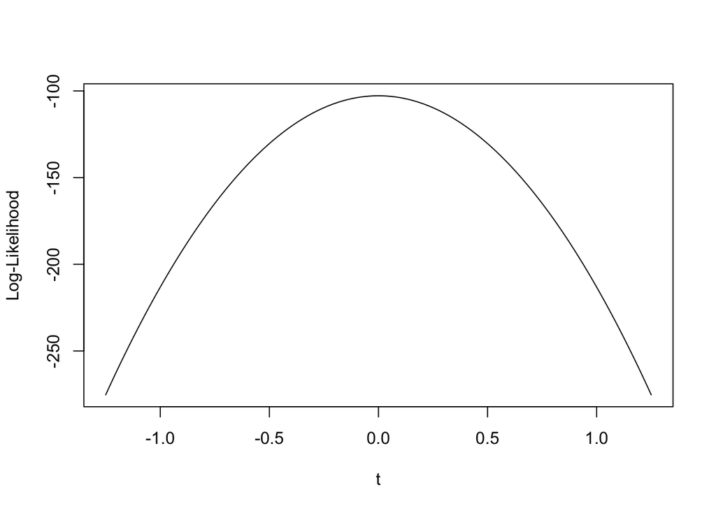

```r
log_likelihood <- function(beta_value, sigma2, X, y) {
  residual <- y - as.vector(X %*% beta_value)
  - (nrow(X) / 2 * log(2 * pi * sigma2)) -
    (sum(residual^2) / (2 * sigma2))
}

e_x2 <- c(0,0,1,0,0,0)

t_values <- seq(-1.25, 1.25, length.out = 200)

loglik_values <- sapply(
  t_values,
  function(t) {
    log_likelihood(
      beta_hat + t * e_x2,
      sigma2_mle,
      X,
      y
    )
  }
)

plot(
  t_values,
  loglik_values,
  type = "l",
  xlab = "t",
  ylab = "Log-Likelihood"
)
```

The graph shows that the Log-Likelihood is maximized at t = 0. This is consistent with the above least squares result because the MLE also maximizes the log-likelihood. Since we started at the MLE, the value of (t) that maximizes the log-likelihood should be 0 because (t=0) leaves the estimated coefficients unchanged.

## Question 3 (Starting values in nonconvex optimization)

Consider the function

$$f(x)=\exp(1.5x)-3(x+6)^2-0.05x^3,$$

with derivative

$$f'(x)=1.5\exp(1.5x)-6(x+6)-0.15x^2.$$

1. Plot $f(x)$ over the interval $[-40,7]$. Based on the plot, describe the important features of the objective function that may affect numerical optimization.
2. Use BFGS to minimize $f(x)$ twice, starting at $x^{(0)}=-15$ and $x^{(0)}=0$. Supply $f'(x)$ to the optimizer. For each run, report the final value of $x$, the final objective value, $|f'(x)|$, and whether the optimizer reported convergence.
3. Explain why the two runs can converge to different answers. Which run gives the lower objective value? What additional evidence would be needed before claiming that this point is the global minimum?

### Solution: Question 3

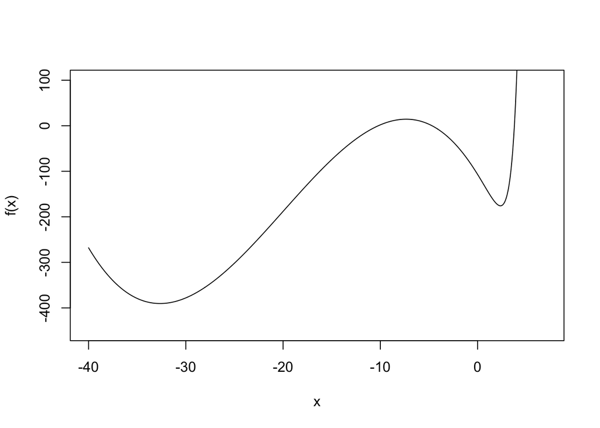

```r
f <- function(x) {
  exp(1.5 * x) - 3 * (x + 6)^2 -0.05 * x^3
}

x_vals <- seq(-40, 7, length.out = 500)

plot(
  x_vals,
  f(x_vals),
  type = "l",
  ylim = c(-450, 100),
  xlab = "x",
  ylab = "f(x)"
)
```

```r
derivative <- function(x) {
  1.5 * exp(1.5 * x) - 6 * (x + 6) - 0.15 * x^2
}

start <- c(-15, 0)
results <- lapply(
  start,
  function(start_value) {
    optim(
      par = start_value,
      fn = f,
      gr = derivative,
      method = "BFGS"
    )
  }
)

results[[1]]$par
```

```
[1] -32.64911
```

```r
results[[1]]$value
```

```
[1] -390.3858
```

```r
abs(derivative(results[[1]]$par))
```

```
[1] 8.725087e-08
```

```r
results[[1]]$convergence
```

```
[1] 0
```

```r
results[[2]]$par
```

```
[1] 2.349967
```

```r
results[[2]]$value
```

```
[1] -175.8626
```

```r
abs(derivative(results[[2]]$par))
```

```
[1] 6.556057e-07
```

```r
results[[2]]$convergence
```

```
[1] 0
```

Starting at $x^{(0)} = -15$, BFGS converged to x = -32.64911 with an objective value of -390.3858 and $|f'(x)| = 8.73 \ X \ 10^{-8}$. Starting at $x^{(0)} = 0$, BFGS converged to x = 2.349967 with an objective value of -175.8626 and $|f'(x)| = 6.56 \ X \ 10^{-7}$. Both runs reported convergence.

The two runs can converge to different answers because the function we are trying to optimize could have multiple local minimums. The run that gave the lower objective value was the run starting at $x^{(0)} = -15$. Before we can call this a global minimum, we would need to try more starting valuses because the minimum BFGS finds can depend on the starting value.

## Question 4 (Nearly collinear predictors)

Continue with $\mathbf X$ and $\mathbf y$ from Question 1. Set the random seed to 43202 and generate

$$u_i\overset{\mathrm{iid}}{\sim}N(0,1),
\qquad i=1,\ldots,n.$$

Define

$$\mathbf x_6=\mathbf x_1+10^{-4}\mathbf u,
\qquad
\mathbf X_+
=
\begin{bmatrix}
\mathbf X & \mathbf x_6
\end{bmatrix},$$

and let

$$\mathbf y^\star=\mathbf y+10^{-3}\mathbf u.$$

Use a numerically stable least-squares routine throughout.

1. Fit $\mathbf y$ using $\mathbf X$ and $\mathbf X_+$. For each design matrix, report the condition number and training RMSE. For the augmented fit, also report the coefficients of $\mathbf x_1$ and $\mathbf x_6$.
2. Fit $\mathbf y^\star$ using $\mathbf X_+$. Report the changes in the coefficients of $\mathbf x_1$ and $\mathbf x_6$. Compare the two fitted-value vectors using their root mean squared difference and maximum absolute difference.
3. Use the identity

$$\mathbf y^\star-\mathbf y
=
10(\mathbf x_6-\mathbf x_1)$$

to explain why the fitted values change very little while the two coefficients change substantially. What does this example suggest about interpreting separate effects for nearly collinear predictors?

### Solution: Question 4

```r
set.seed(43202)

u <- rnorm(n)

x6 <- X[, "x1"] + 10^(-4) * u

X_plus <- cbind(X, x6 = x6)

y_star <- y + 10^(-3) * u

fit_original <- lm.fit(x = X, y = y)
fit_augmented <- lm.fit(x = X_plus, y = y)
fit_perturbed <- lm.fit(x = X_plus, y = y_star)

beta_augmented <- fit_augmented$coefficients
beta_perturbed <- fit_perturbed$coefficients

fitted_augmented <- as.vector(X_plus %*% beta_augmented)
fitted_perturbed <- as.vector(X_plus %*% beta_perturbed)

condition_number <- function(design) {
  singular_values <- svd(design, nu = 0, nv = 0)$d
  max(singular_values) / min(singular_values)
}

condition_number(X)
```

```
[1] 1.524914
```

```r
condition_number(X_plus)
```

```
[1] 20209.2
```

```r
rmse_original <- sqrt(mean(fit_original$residuals^2))
rmse_augmented <- sqrt(mean(fit_augmented$residuals^2))

rmse_original
```

```
[1] 0.6763696
```

```r
rmse_augmented
```

```
[1] 0.6754668
```

```r
beta_augmented[c("x1", "x6")]
```

```
       x1        x6
 351.6766 -350.2588
```

```r
beta_augmented[c("x1", "x6")]
```

```
       x1        x6
 351.6766 -350.2588
```

```r
beta_perturbed[c("x1", "x6")]
```

```
       x1        x6
 341.6766 -340.2588
```

```r
beta_perturbed[c("x1", "x6")] -
  beta_augmented[c("x1", "x6")]
```

```
 x1  x6
-10  10
```

```r
rmse_fitted_difference <- sqrt(
  mean((fitted_perturbed - fitted_augmented)^2)
)

max_fitted_difference <- max(
  abs(fitted_perturbed - fitted_augmented)
)

rmse_fitted_difference
```

```
[1] 0.001015879
```

```r
max_fitted_difference
```

```
[1] 0.002572675
```

The condition number for the original design matrix $X$ was 1.5249, while the condition number for $X_+$ was 20,209.2. The training RMSE was 0.6764 for $X$ and 0.6755 for $X_+$. For the $X_+$ model, the estimated coefficients for $x_1$ and $x_6$ were 351.6766 and -350.2588, respectively.

After changing $y$ to $y^*$, the coefficient for $x_1$ changed from 351.6766 to 341.6766, a decrease of 10. The coefficient for $x_6$ changed from -350.2588 to -340.2588, an increase of 10. Even though the coefficients changed by 10, the fitted values barely changed. The root mean squared difference between the fitted values was 0.001016, and the maximum absolute difference was 0.002573.

The small change in the response is accounted for by decreasing the coefficient of $x_1$ by 10 and increasing the coefficient of $x_6$ by 10. Because they are almost identical, these changes cancel each other out and the fitted values barely change. This shows that when predictors are nearly collinear, their individual coefficients can change a lot even though the model’s predictions stay almost the same. This can be difficult to interpret.

## Question 5 (Data preparation and summary statistics)

The file `data/data-manipulation.csv` is a small constructed data table containing an observation identifier, a group label, two numeric predictors, and a response. Some response values are missing. For analyses involving the response, use only observations with a recorded response. Do not replace a missing response with zero or a group mean.

1. Read the data and report its dimensions, column types, number of duplicated identifiers, and number of missing values in each column. Create an analysis table containing only observations with a recorded response, and define

$$\texttt{feature\_sum}=\texttt{x1}+\texttt{x2}.$$

2. For each group, report the number of observations, the mean response, and the mean of `feature_sum`. State clearly which observations these summaries describe.
3. Sort the analysis table by response from largest to smallest and report the first three rows, including `observation_id`, `group`, `response`, and `feature_sum`. Add code checks verifying that the number of retained rows equals the number of nonmissing responses in the original data, that the analysis table has no missing response values, and that its identifiers are unique.

### Solution: Question 5

```r
data <- read.csv("data/data-manipulation.csv")

dim(data)
```

```
[1] 24  5
```

```r
str(data)
```

```
'data.frame':   24 obs. of  5 variables:
 $ observation_id: chr  "obs-01" "obs-02" "obs-03" "obs-04" ...
 $ group         : chr  "A" "A" "A" "A" ...
 $ x1            : num  1.2 2.4 0.8 3.1 2 1.7 2.8 1 3.5 2.7 ...
 $ x2            : num  2 1.1 2.8 1.5 2.2 1.8 0.9 2.5 1.4 2.3 ...
 $ response      : num  5.36 6.18 4.62 NA 5.52 5.64 7.18 4.7 7.84 7.24 ...
```

```r
sum(duplicated(data$observation_id))
```

```
[1] 0
```

```r
colSums(is.na(data))
```

```
observation_id          group             x1             x2       response
             0              0              0              0              3
```

```r
analysis_data <- data[!is.na(data$response), ]
analysis_data$feature_sum <- analysis_data$x1 + analysis_data$x2
dim(analysis_data)
```

```
[1] 21  6
```

```r
head(analysis_data)
```

```
  observation_id group  x1  x2 response feature_sum
1         obs-01     A 1.2 2.0     5.36         3.2
2         obs-02     A 2.4 1.1     6.18         3.5
3         obs-03     A 0.8 2.8     4.62         3.6
5         obs-05     A 2.0 2.2     5.52         4.2
6         obs-06     A 1.7 1.8     5.64         3.5
7         obs-07     A 2.8 0.9     7.18         3.7
```

```r
group_summary <- aggregate(
  cbind(response, feature_sum) ~ group,
  data = analysis_data,
  FUN = mean
)

group_counts <- table(analysis_data$group)

group_summary
```

```
  group response feature_sum
1     A 5.600000    3.600000
2     B 7.602857    4.928571
3     C 7.997143    6.585714
```

```r
group_counts
```

```
A B C
7 7 7
```

```r
sorted_data <- analysis_data[
  order(analysis_data$response, decreasing = TRUE),
]

sorted_data[1:3, c(
  "observation_id",
  "group",
  "response",
  "feature_sum"
)]
```

```
   observation_id group response feature_sum
22         obs-22     C     9.24         6.6
16         obs-16     B     9.00         5.2
14         obs-14     B     8.66         5.0
```

```r
nrow(analysis_data) == sum(!is.na(data$response))
```

```
[1] TRUE
```

```r
sum(is.na(analysis_data$response)) == 0
```

```
[1] TRUE
```

```r
anyDuplicated(analysis_data$observation_id) == 0
```

```
[1] TRUE
```

The original data has 24 observations and 5 columns. observation_id and group are character variables, while x1, x2, and response are numeric variables. There are no duplicated observation IDs. There are 3 missing values in response and no missing values in the other columns. After removing observations with a missing response and creating feature_sum, the analysis table has 21 observations and 6 columns.

Each group has 7 observations with a recorded response. Group A had a mean response of 5.6000 and a mean feature_sum of 3.6000. Group B had a mean response of 7.6029 and a mean feature_sum of 4.9286. Group C had a mean response of 7.9971 and a mean feature_sum of 6.5857. These summaries only include observations that had a recorded response.

After sorting the analysis table from largest to smallest response, the three highest responses were obs-22 from Group C with a response of 9.24 and feature_sum of 6.6, obs-16 from Group B with a response of 9.00 and feature_sum of 5.2, and obs-14 from Group B with a response of 8.66 and feature_sum of 5.0. All three code checks returned TRUE, confirming that the correct number of observations were retained, there are no missing responses in the analysis table, and all observation IDs are unique.

## Question 6 (Can 39 million Fitbit records represent US adults?)

[Patten et al. (2026)](https://doi.org/10.1038/s41591-026-04352-3) describe Fitbit data from 59,018 participants in the All of Us Research Program. The dataset spans 14 years and contains more than 39 million daily step records. Participants contributed data through one of two routes:

- Bring Your Own Device (BYOD): participants shared data from a Fitbit they already owned.
- Wearables Enhancing All of Us Research (WEAR): invited participants received a Fitbit at no cost.

In the general activity cohort, the BYOD and WEAR groups contained 32,035 and 22,474 participants, respectively. The BYOD value is listed first in each comparison below:

- 77.3% versus 55.1% reported being White;
- 6.1% versus 15.2% reported annual household income between $\$10{,}000$ and $\$25{,}000$; and
- median daily steps were 6,867 versus 5,797.

Suppose the target is the mean of the participant-specific average daily step counts among US adults during the study period, with each adult given equal weight. A researcher writes:

> “This dataset contains more than 39 million daily Fitbit records. Therefore, the average of all recorded step counts should provide an accurate estimate of mean daily activity among US adults.”

Are the 39 million daily records independent observations? What characteristics or behaviors could cause some participants to contribute more recorded days than others? Explain how averaging all recorded days would then weight participants unequally.

BYOD participants reported a median of 6,867 daily steps, compared with 5,797 among WEAR participants. Does this comparison show that already owning a Fitbit causes people to walk more? Explain your answer and give at least one plausible alternative explanation based on how participants entered the two groups.

A very large dataset can still produce a biased estimate of a population quantity when the people and observations entering the dataset are selected. Using this study, explain how selection of both participants and recorded days could make the observed data differ from the US adult population. Why might the naive average of all recorded daily step counts fail to estimate the stated target? You do not need to determine the direction of the bias.

### Solution: Question 6

The daily records are not independent because the same participants contributed data for multiple days. This means that one person’s activity on different days could be related. Some participants may have more recorded days because they wore their Fitbit more consistently, participated for longer, or had less missing data. If all daily records are averaged together, participants with more recorded days will have a greater effect on the average than participants with fewer recorded days. This would not give each adult equal weight.

The difference in median daily steps does not show that already owning a Fitbit causes people to walk more. The participants were not randomly assigned to the BYOD and WEAR groups, so there could be other differences between the groups that explain the difference in steps. For example, people who already owned a Fitbit may have been more interested in exercise or tracking their activity before entering the study. Therefore, already owning a Fitbit may be associated with higher activity without actually causing it.

Even though the dataset is very large, the participants may not be representative of all US adults. People who choose to participate in the study or already own a Fitbit could differ from the general population in ways that are related to their activity levels. The recorded days could also be selected because some participants may wear their Fitbit more consistently than others or may be more likely to wear it on certain days. Because both the participants and the number of recorded days are selected, the average of all recorded daily steps may give more weight to certain types of people and may not accurately estimate the average daily activity of US adults.

### Source

Patten, T., Preble, E. A., Master, H., et al. (2026). [The All of Us Research Program’s wearables dataset](https://doi.org/10.1038/s41591-026-04352-3). *Nature Medicine*, 32, 2302-2310.